# MD 10 Demo

Inference for Regression

2022-11-16

```r
library(tidyverse)
library(infer)
library(moderndive)
library(patchwork)
library(here)
theme_set(theme_minimal())
```

We’re going to look at the bikes example we did before. But now with uncertainty!

```r
d <- bayesrules::bikes
glimpse(d)
```

```
## Rows: 500
## Columns: 13
## $ date        <date> 2011-01-01, 2011-01-03, 2011-01-04, 2011-01-05, 2011-01-0…
## $ season      <fct> winter, winter, winter, winter, winter, winter, winter, wi…
## $ year        <int> 2011, 2011, 2011, 2011, 2011, 2011, 2011, 2011, 2011, 2011…
## $ month       <fct> Jan, Jan, Jan, Jan, Jan, Jan, Jan, Jan, Jan, Jan, Jan, Jan…
## $ day_of_week <fct> Sat, Mon, Tue, Wed, Fri, Sat, Mon, Tue, Wed, Thu, Fri, Sat…
## $ weekend     <lgl> TRUE, FALSE, FALSE, FALSE, FALSE, TRUE, FALSE, FALSE, FALS…
## $ holiday     <fct> no, no, no, no, no, no, no, no, no, no, no, no, no, yes, n…
## $ temp_actual <dbl> 57.39952, 46.49166, 46.76000, 48.74943, 46.50332, 44.17700…
## $ temp_feel   <dbl> 64.72625, 49.04645, 51.09098, 52.63430, 50.79551, 46.60286…
## $ humidity    <dbl> 80.5833, 43.7273, 59.0435, 43.6957, 49.8696, 53.5833, 48.2…
## $ windspeed   <dbl> 10.749882, 16.636703, 10.739832, 12.522300, 11.304642, 17.…
## $ weather_cat <fct> categ2, categ1, categ1, categ1, categ2, categ2, categ1, ca…
## $ rides       <int> 654, 1229, 1454, 1518, 1362, 891, 1280, 1220, 1137, 1368, …
```

Remember this?

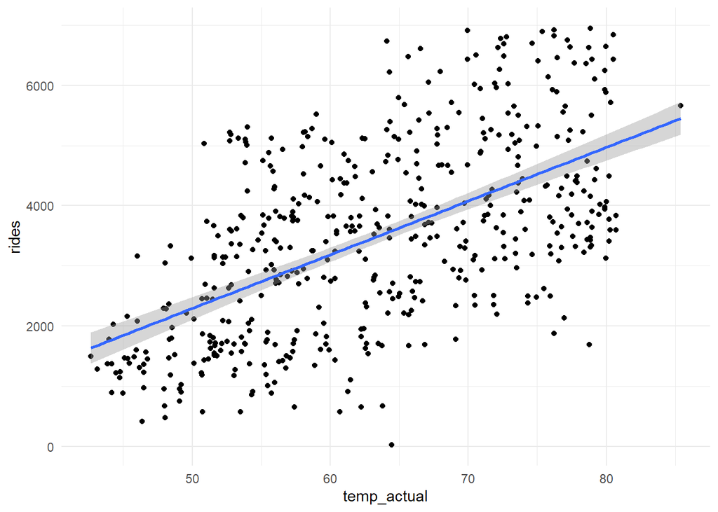

```r
ggplot(d,
       aes(x = temp_actual,
           y = rides)) +
  geom_point() +
  geom_smooth(method = "lm")
```

Where does that gray ribbon come from? It is a confidence interval! Let’s take a look.

```r
m1 <- lm(rides ~ temp_actual,
         data = d)
get_regression_table(m1)
```

```
## # A tibble: 2 × 7
##   term        estimate std_error statistic p_value lower_ci upper_ci
##   <chr>          <dbl>     <dbl>     <dbl>   <dbl>    <dbl>    <dbl>
## 1 intercept    -2169.     364.       -5.96       0  -2883.    -1454.
## 2 temp_actual     89.2      5.67     15.7        0     78.1     100.
```

A few things to note:

- `intercept` is the intercept (obviously!)
- `temp_actual` is the slope ($\hat{\beta}$) (we’re going to focus on the slope)
- the **standard error** is the *standard deviation* of the theoretical sampling distribution (that is, not based on simulations like what we’ve done before)
- `lower_ci` and `upper_ci` stand for the lower and upper bounds of the 95% confidence interval
  - the lower bound is $\hat{\beta} - 1.96 \times \text{standard error of } \hat{\beta}$
  - the upper bound is $\hat{\beta} + 1.96 \times \text{standard error of } \hat{\beta}$

Don’t worry about the other columns just yet.

How can we get confidence intervals with our simulation approach?

```r
set.seed(1234)

boot_dist <- d |>
  specify(formula = rides ~ temp_actual) |>
  generate(reps = 1000, type = "bootstrap") |>
  calculate(stat = "slope")

boot_dist
```

```
## Response: rides (numeric)
## Explanatory: temp_actual (numeric)
## # A tibble: 1,000 × 2
##    replicate  stat
##        <int> <dbl>
##  1         1  82.7
##  2         2  87.5
##  3         3  93.5
##  4         4  84.7
##  5         5  85.5
##  6         6 101.
##  7         7  96.7
##  8         8  89.2
##  9         9  91.4
## 10        10  87.4
## # … with 990 more rows
```

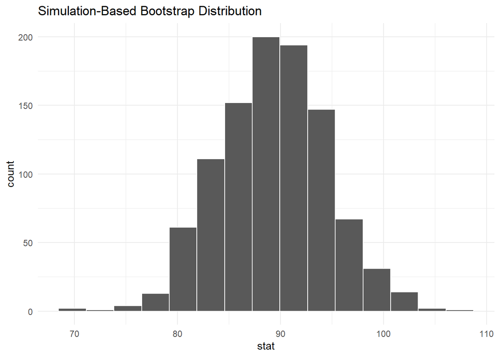

```r
visualize(boot_dist)
```

We can use this to get the confidence interval like before.

#### numeric

```r
ci <- boot_dist |>
  get_ci(level = .95, type = "percentile")

ci
```

```
## # A tibble: 1 × 2
##   lower_ci upper_ci
##      <dbl>    <dbl>
## 1     79.7     99.4
```

#### visual

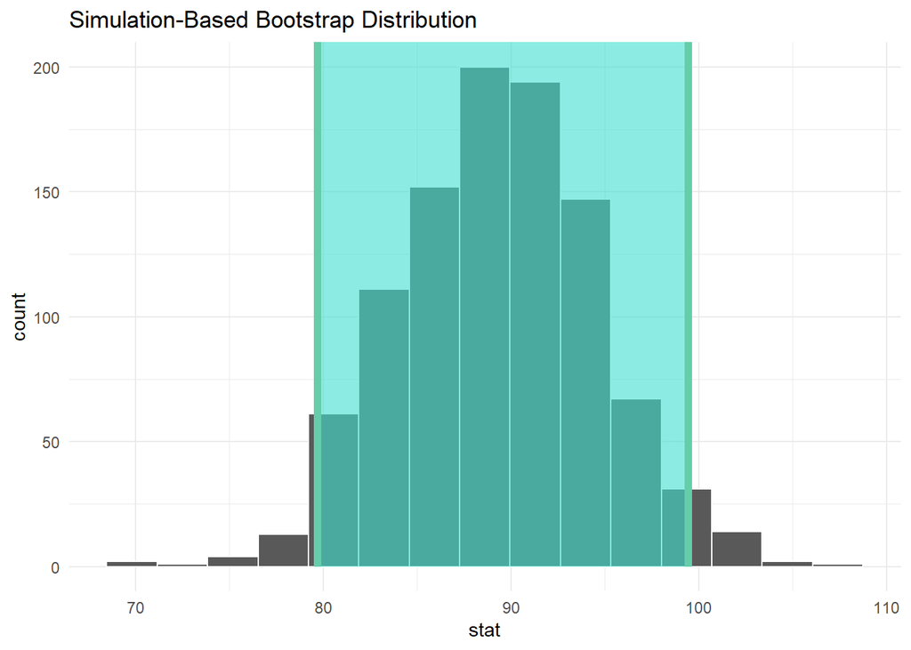

```r
visualise(boot_dist) +
  shade_ci(ci)
```

How does this compare to what we got from `lm()`?

```r
get_regression_table(m1)
```

```
## # A tibble: 2 × 7
##   term        estimate std_error statistic p_value lower_ci upper_ci
##   <chr>          <dbl>     <dbl>     <dbl>   <dbl>    <dbl>    <dbl>
## 1 intercept    -2169.     364.       -5.96       0  -2883.    -1454.
## 2 temp_actual     89.2      5.67     15.7        0     78.1     100.
```

Pretty close but not the same! We won’t worry too much about why these are different but you should be aware of the fact that they will generally be close but different.

# Hypothesis testing

Again, it’s the same idea as the other day. We can do hypothesis testing a couple of different ways.

First, what would the null hypothesis be in this case?

(The null is that the slope is ZERO. This might not be that interesting, but it is the conventional null hypothesis.)

#### Confidence interval

The “test” of the null is whether my 95% confidence interval includes zero. As we saw above, it does not!

#### p-value

```r
set.seed(1234)

# get observe slope
obs_slope <- d |>
  specify(formula = rides ~ temp_actual) |>
  calculate(stat = "slope")

obs_slope
```

```
## Response: rides (numeric)
## Explanatory: temp_actual (numeric)
## # A tibble: 1 × 1
##    stat
##   <dbl>
## 1  89.2
```

```r
# compare to null distribution
null_dist <- d |>
  specify(formula = rides ~ temp_actual) |>
  hypothesize(null = "independence") |>
  generate(reps = 1000) |>
  calculate(stat = "slope")

boot_dist
```

```
## Response: rides (numeric)
## Explanatory: temp_actual (numeric)
## # A tibble: 1,000 × 2
##    replicate  stat
##        <int> <dbl>
##  1         1  82.7
##  2         2  87.5
##  3         3  93.5
##  4         4  84.7
##  5         5  85.5
##  6         6 101.
##  7         7  96.7
##  8         8  89.2
##  9         9  91.4
## 10        10  87.4
## # … with 990 more rows
```

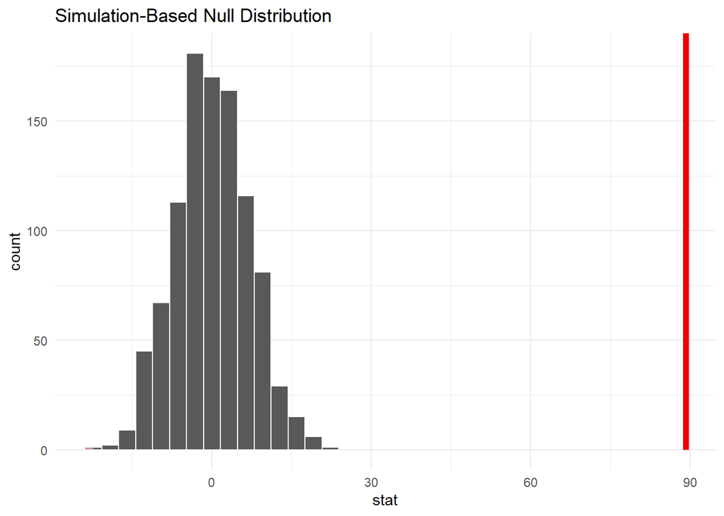

```r
visualize(null_dist) +
  shade_p_value(obs_stat = obs_slope,
                direction = "both")
```

Remember this?

```r
get_regression_table(m1)
```

```
## # A tibble: 2 × 7
##   term        estimate std_error statistic p_value lower_ci upper_ci
##   <chr>          <dbl>     <dbl>     <dbl>   <dbl>    <dbl>    <dbl>
## 1 intercept    -2169.     364.       -5.96       0  -2883.    -1454.
## 2 temp_actual     89.2      5.67     15.7        0     78.1     100.
```

This is why the p-value shows up as 0 in the regression table. Because, for all intents and purposes, a result as extreme as 89.2 would never happen by chance! The theoretical p-value here isn’t literally zero, but is about $2 \times 10^{-16}$.

# Some pitfalls to look out for

The book tells you to look out for a few things when you are doing inference on regression slopes. The checks you want to do are:

1. **L**inearity of the relationships
2. **I**ndependence of residuals
3. **N**ormality of the residuals
4. **E**quality of the variance of the residuals

Only one of these is really important, which is **linearity of the relationships.** If you use a regression in your final paper, be sure to check this!

Consider the following:

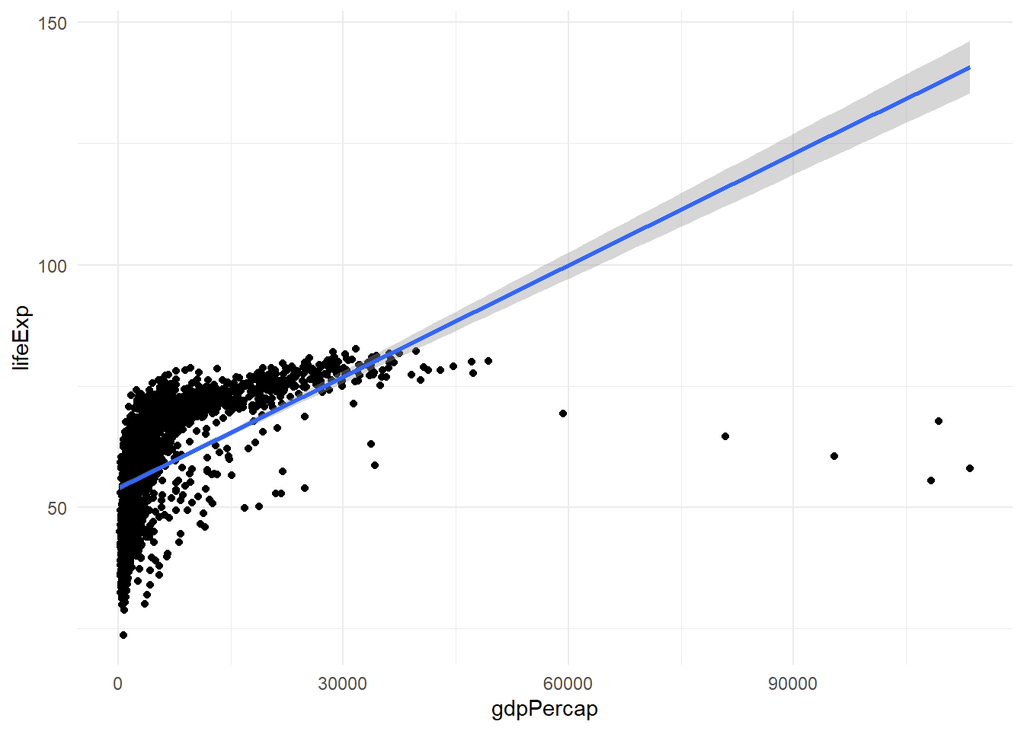

```r
d2 <- gapminder::gapminder

ggplot(d2,
       aes(y = lifeExp,
           x = gdpPercap)) +
  geom_point() +
  geom_smooth(method = "lm")
```

```r
m2 <- lm(lifeExp ~ gdpPercap,
         data = d2)

m2_points <- get_regression_points(m2)
```

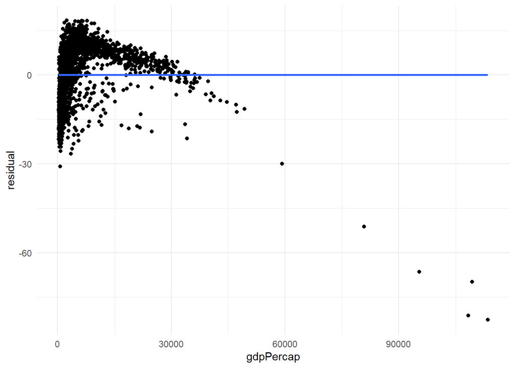

```r
ggplot(m2_points,
       aes(y = residual,
           x = gdpPercap)) +
  geom_point() +
  geom_smooth(method = "lm",
              se = FALSE)
```

In a residual plot, the residuals should be scattered randomly around the line. If there is a pattern, the reliationship is probably not linear.

Compare this:

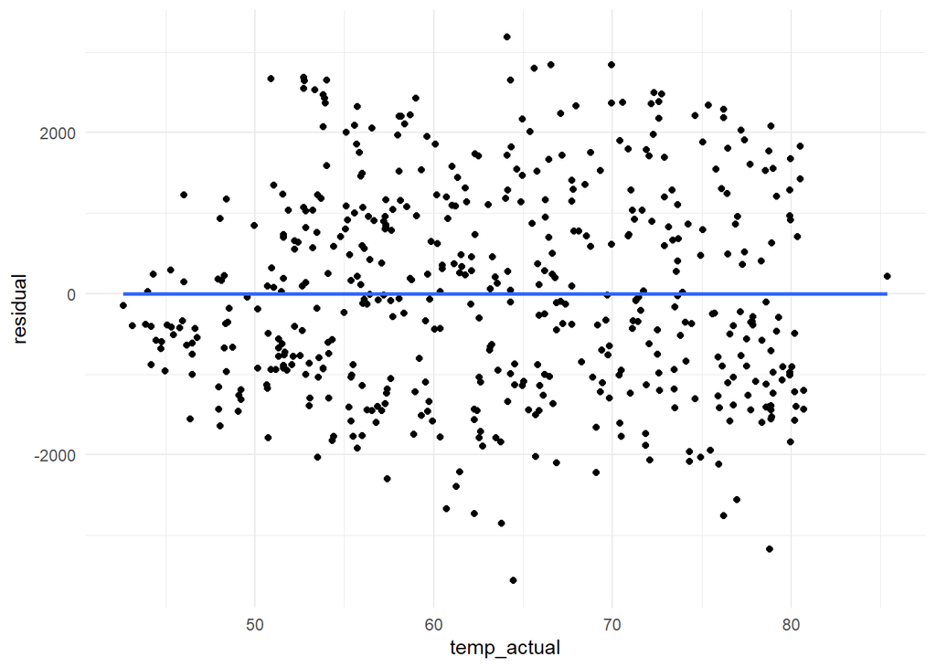

```r
m1_points <- get_regression_points(m1)

ggplot(m1_points,
       aes(y = residual,
           x = temp_actual)) +
  geom_point() +
  geom_smooth(method = "lm",
              se = FALSE)
```